# Homework 10

Solutions for Questions 1 and 2 will be available after Monday, November 2, 2026. No solution will be provided for Question 3.

Use the RLT package for Questions 1 and 2: `RLT` in R or `rlt` in Python. The node-size parameter is `nmin` in R and `min_samples_leaf` in Python; both stop splitting a node when it contains at most that many observations. The candidate-predictor parameter is `mtry` in both languages. Use ordinary random forests, with reinforcement turned off.

## Question 1: Bias-variance trade-off simulation

Two important tuning parameters of random forests are node size and `mtry`. We have performed some preliminary analysis in class. The goal of this question is to perform a larger simulation study for these two tuning parameters.

Consider a regression model with five jointly normally distributed predictors. Each predictor has mean 0 and variance 1, and the correlation between any two different predictors is 0.3. The response is

$$Y=X_1+X_3+X_5+\varepsilon,
\qquad \varepsilon\sim N(0,1),$$

where the noise is independent of the predictors. Thus the true regression function is $f(\mathbf{x})=x_1+x_3+x_5$.

1. Set up a simulation study with 100 repetitions. Generate 200 test predictor vectors once and keep them fixed. In each repetition, generate 200 new training observations and use the same training data for all tuning settings. Fit 500-tree forests, drawing 200 observations with replacement for each tree. Make the following two comparisons:
   - Fix `mtry` at 3 and vary node size over $1,5,10,20,30$.
   - Fix node size at 10 and vary `mtry` over $1,2,3,4,5$.

   Leave all other fitting parameters at their defaults. Record the predictions at each test point across repetitions. For each setting, estimate the squared bias and variance at each test point, then average them over the 200 test points. Compare predictions with $f(\mathbf{x})$ when estimating bias. Produce two figures, one for each tuning parameter, showing the averaged squared bias and variance. Set a random seed and report it.

```
Question 1(a) seed: 111
 mtry  node_size  Squared bias  Variance
    3          1        0.1560    0.2011
    3          5        0.2632    0.1550
    3         10        0.4500    0.1467
    3         20        0.8663    0.1493
    3         30        1.3083    0.1486
    1         10        0.9650    0.0723
    2         10        0.5526    0.1047
    4         10        0.4226    0.1858
    5         10        0.4067    0.2167
```

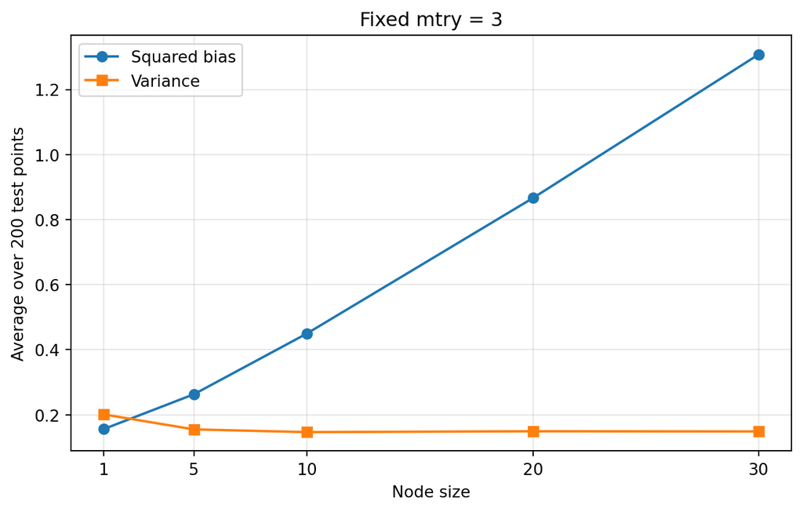

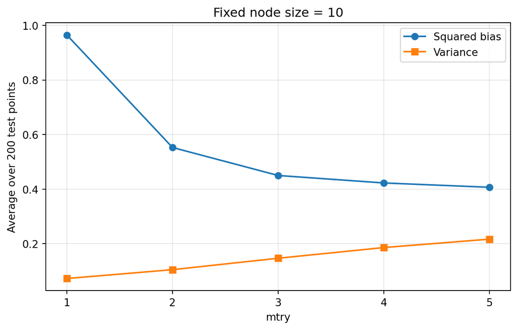

```python
import numpy as np
import pandas as pd
import matplotlib.pyplot as plt
from sklearn.ensemble import RandomForestRegressor

seed = 111
rng = np.random.default_rng(seed)
print(f"Question 1(a) seed: {seed}")

n_train = n_test = 200
n_repetitions = 100
cov = np.full((5, 5), 0.3)
np.fill_diagonal(cov, 1.0)

def f(X):
    return X[:, [0, 2, 4]].sum(axis=1)

X_test = rng.multivariate_normal(np.zeros(5), cov, size=n_test)
f_test = f(X_test)
node_sizes = [1, 5, 10, 20, 30]
mtry_values = [1, 2, 3, 4, 5]
settings = list(dict.fromkeys(
    [(3, size) for size in node_sizes] + [(m, 10) for m in mtry_values]
))
predictions = np.empty((n_repetitions, n_test, len(settings)))

for repetition in range(n_repetitions):
    X_train = rng.multivariate_normal(np.zeros(5), cov, size=n_train)
    y_train = f(X_train) + rng.normal(size=n_train)

    for j, (mtry, node_size) in enumerate(settings):
        forest = RandomForestRegressor(
            n_estimators=500,
            max_features=mtry,
            min_samples_leaf=node_size,
            bootstrap=True,
            max_samples=n_train,
            random_state=int(rng.integers(1, 2**31 - 1)),
        ).fit(X_train, y_train)
        predictions[repetition, :, j] = forest.predict(X_test)

mean_prediction = predictions.mean(axis=0)
squared_bias = ((mean_prediction - f_test[:, None])**2).mean(axis=0)
variance = predictions.var(axis=0, ddof=0).mean(axis=0)
results_1a = pd.DataFrame(settings, columns=["mtry", "node_size"])
results_1a["Squared bias"] = squared_bias
results_1a["Variance"] = variance
print(results_1a.round(4).to_string(index=False))

for parameter, fixed_value, values, title in [
    ("node_size", 3, node_sizes, "Fixed mtry = 3"),
    ("mtry", 10, mtry_values, "Fixed node size = 10"),
]:
    fixed_parameter = "mtry" if parameter == "node_size" else "node_size"
    table = results_1a.loc[
        results_1a[fixed_parameter].eq(fixed_value)
    ].sort_values(parameter)
    fig, ax = plt.subplots(figsize=(7, 4.5))
    ax.plot(table[parameter], table["Squared bias"], "o-", label="Squared bias")
    ax.plot(table[parameter], table["Variance"], "s-", label="Variance")
    ax.set(
        xlabel="Node size" if parameter == "node_size" else "mtry",
        ylabel="Average over 200 test points",
        title=title,
        xticks=values,
    )
    ax.legend()
    ax.grid(alpha=0.3)
    fig.tight_layout()
    plt.show()
```

2. Discuss your results in terms of the bias-variance trade-off:
   - How does a large node size, such as 30, affect the fit in this example?
   - What are the benefits and drawbacks of using a large `mtry` value?
   - If each tree instead sampled 100 observations with replacement, would you expect the preferred node size to shift toward smaller or larger values? Explain your reasoning. You may use an additional simulation to help, but a particular pattern is not guaranteed.

Large node size will produce substantial bias and smaller variance. Benefits of large mtry is lower bias. However, it will produce larger variance. Smaller sampled observations will produce larger bias. Therefore, preferred node size should decrease to capture more information.

## Question 2: Tuning random forests for MNIST

Use `mnist-first2000.csv.gz` from the combined ZIP. It contains 2,000 MNIST observations, with the digit label `Digit` and 784 pixel values.

- From the first 1,000 observations, keep digits 1, 6, and 7 as the training data. From the remaining 1,000 observations, keep the same digits as the test data.
- Fit PCA to the training pixels, centering but not scaling them. Use the first 20 principal components as predictors, and project the test observations using the same training means and loadings.

Complete the following tasks using RLT classification forests with 1,000 trees. For each tree, draw a bootstrap sample of the same size as the training set.

1. Fit a random forest with the default `mtry` and node-size settings. Report the out-of-bag (OOB) misclassification rate.

```python
from pathlib import Path
import numpy as np
import pandas as pd
from sklearn.decomposition import PCA
from sklearn.ensemble import RandomForestRegressor
from sklearn.metrics import confusion_matrix

seed2 = 111
print(f"Question 2 seed: {seed2}")
data_path = Path("data/mnist-first2000.csv.gz")
if not data_path.exists():
    data_path = Path("homework/week-10/data/mnist-first2000.csv.gz")
mnist = pd.read_csv(data_path)
digit_classes = np.array([1, 6, 7])
train_digits = mnist.iloc[:1000]
train_digits = train_digits.loc[train_digits["Digit"].isin(digit_classes)]
pixel_columns = mnist.columns.drop("Digit")
y_train_digits = train_digits["Digit"].to_numpy()
Y_train_onehot = (y_train_digits[:, None] == digit_classes).astype(float)

pca2 = PCA(n_components=20, svd_solver="full")
X_train_pca = pca2.fit_transform(train_digits[pixel_columns].to_numpy())
print(f"Training observations: {len(y_train_digits)}")

def predict_digit(scores):
    return digit_classes[np.argmax(scores, axis=1)]

def fit_digit_forest(**settings):
    return RandomForestRegressor(
        n_estimators=1000,
        bootstrap=True,
        max_samples=len(y_train_digits),
        oob_score=True,
        n_jobs=-1,
        random_state=seed2,
        **settings,
    ).fit(X_train_pca, Y_train_onehot)

def oob_misclassification(model):
    return np.mean(predict_digit(model.oob_prediction_) != y_train_digits)

default_forest = fit_digit_forest()
default_oob_error = oob_misclassification(default_forest)
print(f"Default OOB misclassification rate: {default_oob_error:.4f}")
```

```
Question 2 seed: 111
Training observations: 327
Default OOB misclassification rate: 0.0489
```

2. Construct a grid of `mtry` and node-size values to tune the model. Select the setting using OOB misclassification rate. Report the OOB error for each setting and the selected values. Calculate and present the selected forest’s OOB permutation variable importance for the 20 principal components. Comment on your results.

```python
mtry_grid = [2, 4, 6, 10, 20]
node_size_grid = [1, 3, 5, 10]
best_forest = default_forest
best_mtry, best_node_size = 20, 1
best_oob_error = default_oob_error
tuning_rows = []

for mtry in mtry_grid:
    for node_size in node_size_grid:
        if (mtry, node_size) == (20, 1):
            model = default_forest
        else:
            model = fit_digit_forest(
                max_features=mtry, min_samples_leaf=node_size
            )
        error = oob_misclassification(model)
        tuning_rows.append((mtry, node_size, error))
        if error < best_oob_error:
            best_forest = model
            best_mtry, best_node_size = mtry, node_size
            best_oob_error = error

tuning_results = pd.DataFrame(
    tuning_rows, columns=["mtry", "node_size", "OOB error"]
)
print(tuning_results.round(4).to_string(index=False))
print(
    f"Selected mtry = {best_mtry}, node size = {best_node_size}; "
    f"OOB misclassification rate = {best_oob_error:.4f}"
)

permutation_rng = np.random.default_rng(seed2)
tree_importance = np.empty((len(best_forest.estimators_), 20))

for b, (tree, sampled_rows) in enumerate(zip(
    best_forest.estimators_, best_forest.estimators_samples_
)):
    oob_rows = np.flatnonzero(
        np.bincount(sampled_rows, minlength=len(y_train_digits)) == 0
    )
    X_oob = X_train_pca[oob_rows]
    y_oob = y_train_digits[oob_rows]
    base_error = np.mean(predict_digit(tree.predict(X_oob)) != y_oob)
    for j in range(20):
        X_permuted = X_oob.copy()
        X_permuted[:, j] = permutation_rng.permutation(X_permuted[:, j])
        permuted_error = np.mean(
            predict_digit(tree.predict(X_permuted)) != y_oob
        )
        tree_importance[b, j] = permuted_error - base_error

importance_results = pd.DataFrame({
    "PC": [f"PC{j}" for j in range(1, 21)],
    "OOB permutation importance": tree_importance.mean(axis=0),
})
print(importance_results.round(4).to_string(index=False))
```

```
 mtry  node_size  OOB error
    2          1     0.0367
    2          3     0.0398
    2          5     0.0428
    2         10     0.0398
    4          1     0.0398
    4          3     0.0398
    4          5     0.0398
    4         10     0.0459
    6          1     0.0398
    6          3     0.0428
    6          5     0.0489
    6         10     0.0489
   10          1     0.0398
   10          3     0.0428
   10          5     0.0459
   10         10     0.0459
   20          1     0.0489
   20          3     0.0520
   20          5     0.0550
   20         10     0.0520
Selected mtry = 2, node size = 1; OOB misclassification rate = 0.0367
  PC  OOB permutation importance
 PC1                      0.1422
 PC2                      0.1969
 PC3                      0.0400
 PC4                      0.0163
 PC5                      0.0355
 PC6                      0.0353
 PC7                      0.0199
 PC8                      0.0099
 PC9                      0.0071
PC10                      0.0122
PC11                      0.0222
PC12                      0.0118
PC13                      0.0102
PC14                      0.0149
PC15                      0.0065
PC16                      0.0125
PC17                      0.0091
PC18                      0.0181
PC19                      0.0114
PC20                      0.0140
```

With seed 111, the selected setting is `mtry = 2` and minimum leaf size 1. Its OOB misclassification rate is 3.67%, compared with 4.89% for the default forest. PC2 and PC1 have the largest OOB permutation importance, followed by PC3.

3. Apply the selected model to the test data and report the misclassification rate and confusion matrix. Use the test labels only for this final assessment.

```python
test_digits = mnist.iloc[1000:2000]
test_digits = test_digits.loc[test_digits["Digit"].isin(digit_classes)]
X_test_pca = pca2.transform(test_digits[pixel_columns].to_numpy())
y_test_digits = test_digits["Digit"].to_numpy()
test_predictions = predict_digit(best_forest.predict(X_test_pca))
test_error = np.mean(test_predictions != y_test_digits)
confusion = pd.DataFrame(
    confusion_matrix(y_test_digits, test_predictions, labels=digit_classes),
    index=pd.Index(digit_classes, name="Actual"),
    columns=pd.Index(digit_classes, name="Predicted"),
)
print(f"Test observations: {len(y_test_digits)}")
print(f"Test misclassification rate: {test_error:.4f}")
print(confusion)
```

```
Test observations: 317
Test misclassification rate: 0.0158
Predicted    1    6    7
Actual
1          102    0    2
6            0  106    0
7            0    3  104
```

## Question 3: Planning a random-forest analysis skill

In earlier homework, some students wrote long skill files with detailed instructions, while others wrote short skills emphasizing their specific requirements or references. These approaches may perform differently depending on the AI and the task. A capable AI may already know standard ways to perform an analysis, so some instructions may be redundant, add little value, or sometimes make the analysis worse. It may be more useful to specify your personal choices for the analysis. An AI with more limited knowledge may benefit from detailed instructions that remind it of the steps to perform.

1. Write one paragraph describing how you would write a skill that directs an AI to perform a random-forest analysis and produce a report for a future dataset. Discuss how you would balance standard analysis instructions with your personal preferences, considering the AI’s capabilities.

I will ask AI to use random forest model. I will select the performance metric and the range of fine tune.

2. Provide **10 instructions** you would consider including in the skill, **ordered from the most basic instructions to the more personal preferences**. Your list may cover computation, tuning, tables, figures, interpretation, presentation, or other aspects of a random-forest report.

You only need to discuss how the skill should be written. You are not required to write a complete skill file or test it.

1. Identify the response and predictors, and determine whether the task is regression or classification.
2. Check variable types, missing values, and inconsistent entries before fitting the model.
3. Set and report a random seed so that the analysis can be reproduced.
4. Keep an independent test set, and fit any preprocessing steps using only the training data.
5. Fit a baseline random forest and report its fitting settings and OOB performance.
6. Use OOB performance or cross-validation to select tuning parameters, then evaluate the selected model on the test set.
7. Report the selected model’s performance, permutation variable importance, and main limitations.
8. Use the performance metric I specify consistently when evaluating and comparing models.
9. Tune `mtry` and node size over the candidate values I provide, keeping the other fitting parameters fixed.
10. Present all candidate settings and their OOB or validation scores in a table, and explain the selection in terms of my chosen metric and tuning range.